# Tutorial 1: Quality Control and Preprocessing of the snATAC-seq Data

Iguaracy Souza, Thodoris Koutsandreas, Umran Yaman

### Dataset

The initial dataset contains more than 170k snATAC-seq samples and could be found here: [PeakMatrix.TSS6.cleaned.rds](https://personal.broadinstitute.org/bjames/AD_snATAC/TSS6_highQC). In this project, only a subset of that dataset will be used, in order to reduce the necessary resources to analyze the data, as well as the execution time. This subset was created by down sampling each cell type separately in order to have a maximum of 3500 cells. The subset() function was used for this task.

Loading of the required libraries for the quality control of the scATAC-seq dataset.

```r
suppressPackageStartupMessages({
    library(ggplot2)
    library(SingleCellExperiment)
    library(Seurat)
    library(Signac)
    library(EnsDb.Hsapiens.v86)
    library(biovizBase)
    library(Matrix)
})
```

### 1. Creation of Seurat Object for the snATAC-seq Data

The downsampled dataset is in SingleCellExperiment format. It needs to be transformed into a Seurat object in order to generate the chromatin assay.

```r
sce_obj <- readRDS("../data/initial_data/downsampled_snATAC_sce_obj.rds")

# Extract the counts
counts <- assay(sce_obj, "PeakMatrix")

# Create a new Seurat object
snATAC_seurat_obj <- CreateSeuratObject(counts = counts)

# Add the metadata for cells
metadata <- as.data.frame(colData(sce_obj))
rownames(metadata) <- colnames(snATAC_seurat_obj)
snATAC_seurat_obj@meta.data <- metadata

# Extract genomic ranges and create a Chromatin Assay
granges <- rowRanges(sce_obj)
annotation <- GetGRangesFromEnsDb(ensdb = EnsDb.Hsapiens.v86)
seqlevels(annotation) <- paste0("chr", seqlevels(annotation))
genome(annotation) <- "hg38"
chrom_assay <- CreateChromatinAssay(counts = counts, ranges = granges,
  genome = "hg38", annotation = annotation)
snATAC_seurat_obj[["ATAC"]] <- chrom_assay
DefaultAssay(snATAC_seurat_obj) <- "ATAC"
```

```r
# Remove the initial and intermediate objects as we need only snATAC_seurat_obj for the
# downstream processing.
counts <- NULL
chrom_assay <- NULL
sce_obj <- NULL
gc()
```

```
##             used   (Mb) gc trigger   (Mb)  max used   (Mb)
## Ncells  14672269  783.6   22118362 1181.3  22118362 1181.3
## Vcells 476134796 3632.7  968005473 7385.3 901411220 6877.3
```

### 2. Transcription Start Site (TSS) Enrichment Score and Quality Control

TSS enrichment scores and quality control plots are generated to assess the distribution and enrichment of peaks around transcription start sites. These plots help to evaluate the quality and reliability of the ATAC-seq data, by examining the distribution of peaks relative to TSS.

The DensityScatter() function enables visualization of the connections between variables stored in the object metadata. Additionally, it serves as a rapid tool for identifying appropriate cutoff values for various QC metrics when quantiles=TRUE is specified.

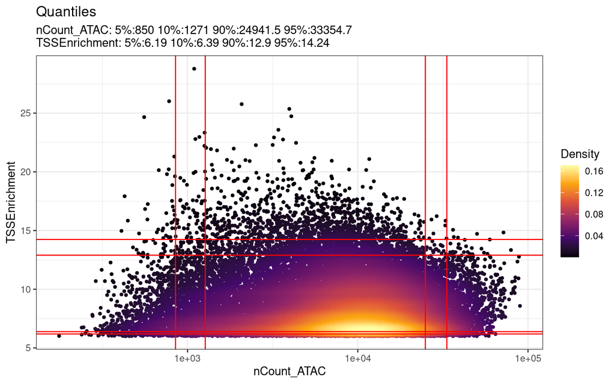

```r
DensityScatter(snATAC_seurat_obj, x = "nCount_ATAC", y = "TSSEnrichment",
  log_x = TRUE, quantiles = TRUE)
```

#### QC Metrics - Violin Plot

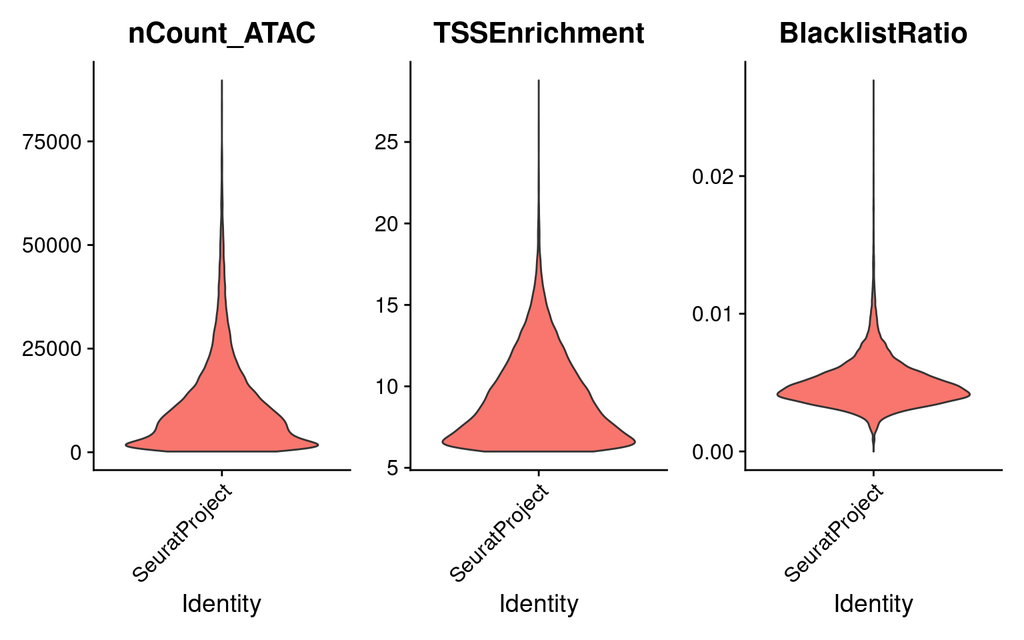

```r
# QC Metrics Violin Plot
VlnPlot(
  object = snATAC_seurat_obj,
  features = c("nCount_ATAC", "TSSEnrichment", "BlacklistRatio"),
  pt.size = 0.0,
  ncol = 3
)
```

#### Removal of Outliers

Outliers will be defined based on the number of peaks, TSS enrichment, and the proportion of peaks in blacklist regions. At the end of this step, only high-quality cells will be retained for the downstream analysis.

```r
# Before QC filtering
print(dim(snATAC_seurat_obj))
```

```
## [1] 363775  22198
```

```r
snATAC_seurat_obj <- subset(
  x = snATAC_seurat_obj,
  subset = nCount_ATAC > 5000 &
    nCount_ATAC < 40000 &
    BlacklistRatio < 0.05 &
    TSSEnrichment > 3
)

# After QC filtering
print(dim(snATAC_seurat_obj))
```

```
## [1] 363775  13895
```

```r
# Remove old object and clean-up the space
```

### 3. Normalization and Linear Dimensionality Reduction

#### 3.1. Normalization

Normalization in Signac involves a two-step process, utilizing Term Frequency-Inverse Document Frequency (TF-IDF) normalization. This normalization is performed across cells to address differences in cellular sequencing depth and across peaks, assigning higher values to rarer peaks.

#### 3.3. Dimensionality reduction

For dimensionality reduction, Signac employs the method of Singular Value Decomposition (SVD) on the TF-IDF matrix, using the previously selected features (peaks). This process yields a reduced-dimension representation of the object, akin to the output of Principal Component Analysis (PCA) in snRNA-seq.

In the following block, three different tasks are performed:

1. Finding of the top features
2. Execution of the TF-IDF normalization
3. Dimensionality reduction with SVD (Singular Value Decomposition)

```r
# Find top features, run TF-IDF, and run SVD for normalization and linear dimensional
# reduction
snATAC_seurat_obj <- FindTopFeatures(snATAC_seurat_obj, min.cutoff = 5)
snATAC_seurat_obj <- RunTFIDF(snATAC_seurat_obj)
snATAC_seurat_obj <- RunSVD(snATAC_seurat_obj)
```

### 4. Depth Correlation Plot

The initial Latent Semantic Indexing (LSI) component frequently reflects sequencing depth, representing technical variation rather than biological differences. In such instances, it is advisable to exclude this component from subsequent analyses. The correlation between each LSI component and sequencing depth can be evaluated using the DepthCor() function. In other words, a correlation plot is created, using the DepthCor() function, in order to assess the correlation between the number of sequencing reads (depth) and other QC metrics. We can check for potential biases related to sequencing depth in the dataset.

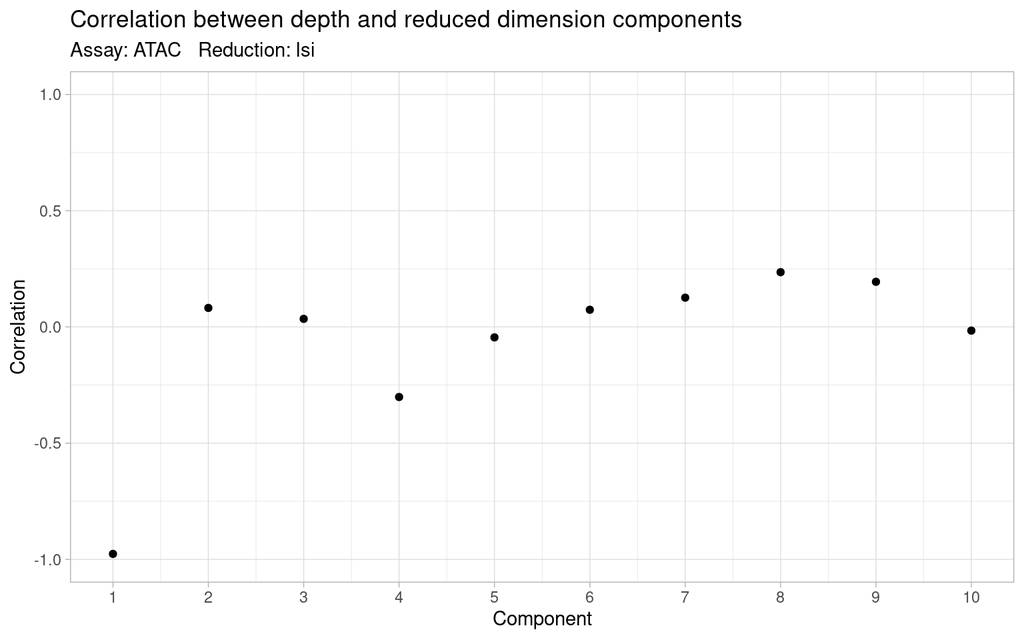

```r
# Depth Correlation Plot
DepthCor(snATAC_seurat_obj)
```

### 5. Uniform Manifold Approximation and Projection (UMAP) and Clustering

We can perform dimensionality reduction running the UMAP method and using the SVD dimensions from 2 to 30, because usually the first one is related to technical biases.

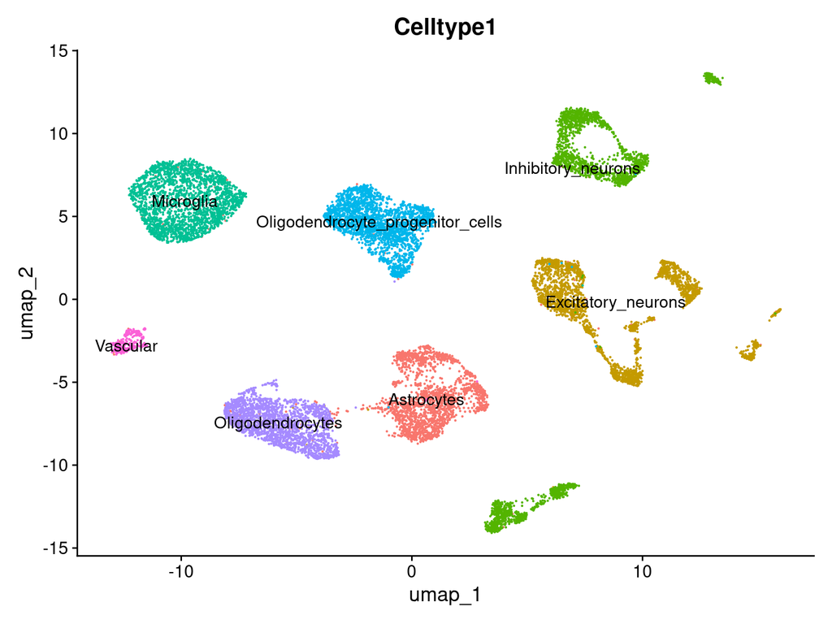

```r
# Non-linear dimension reduction and clustering using UMAP
snATAC_seurat_obj <- RunUMAP(object = snATAC_seurat_obj,
  reduction = "lsi", dims = 2:30)

DimPlot(object = snATAC_seurat_obj, label = TRUE,
  group.by = "Celltype1") + NoLegend()
```

### 6. Integration of the Gene Scores

```r
gene_scores_obj <- readRDS("../data/initial_data/downsampled_snATAC_gene_scores_sumexp_obj.rds")
gene_names <- rowData(gene_scores_obj)$name

# Get the cell names from the Seurat object and search for the respective part of gene scores
# matrix
qc_cells <- colnames(snATAC_seurat_obj)

# Before the subsetting
print(dim(gene_scores_obj))
```

```
## [1] 24919 22198
```

```r
gene_scores_obj <- gene_scores_obj[, qc_cells]
# After the subsetting
dim(gene_scores_obj)
```

```
## [1] 24919 13895
```

```r
# Integrate the gene scores matrix gene_score_matrix <- assay(gene_scores_obj,
# 'GeneScoreMatrix') rownames(gene_score_matrix) <- gene_names snATAC_seurat_obj[['ACTIVITY']]
# <- CreateAssayObject(counts = gene_score_matrix)
```

### 7. Normalization of Gene Scores

```r
# DefaultAssay(snATAC_seurat_obj) <- 'ACTIVITY' snATAC_seurat_obj <-
# NormalizeData(snATAC_seurat_obj) snATAC_seurat_obj <- ScaleData(snATAC_seurat_obj, features
# = rownames(snATAC_seurat_obj))
```

### 8. Saving of the QC and Preprocessed Dataset

```r
saveRDS(snATAC_seurat_obj, file = "../data/snATAC_qc_seurat_obj.rds")
```